# ggplot2 系列

Yuting Fan

11/3/2020

## Theme

Customize the non-data components of your plots: i.e. titles, labels, fonts, background, guidelines, and legends. [link](https://ggplot2.tidyverse.org/reference/theme.html)

## Contour map

利用 ggplot2 畫 contour map (basic 中會用 image.plot)

1. 利用 `for` 迴圈產生 surface 值 (是否有更好的方法?)
2. 利用 `spatstat::im` to creates an object of class “im” representing a two-dimensional pixel image. 這可以使原本25x25的資料，轉成625x3 (tidy data format)
3. 利用 `geom_raster` + `fill` 畫
4. 外觀
   1. 利用 `scale_fill_gradientn` 調整顏色 (blue2green2red 是 colorRamps package中的調色盤)
   2. 例用 `guide` legend 調整長度

※ 詳見 file = “~/Documents/3_Research/201810_GWR/script/1_simulation_mgwrpaper/design_1/design_1.R”

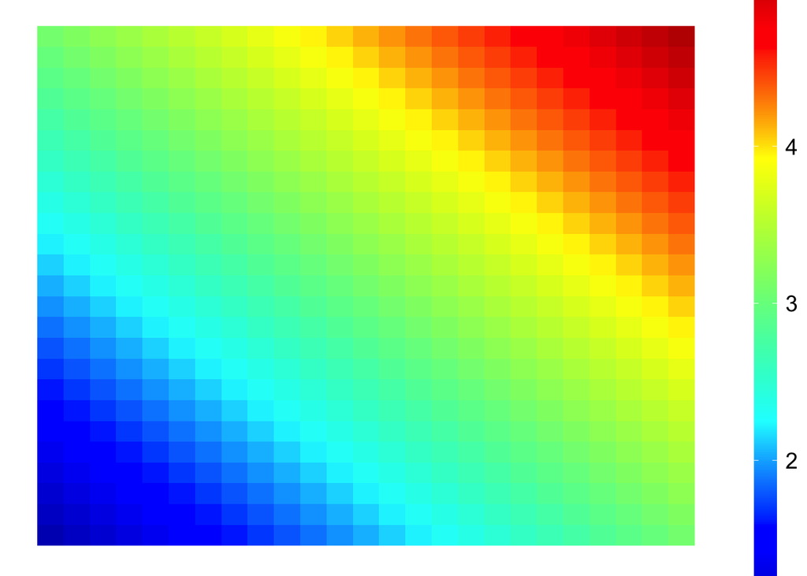

```r
grid_max <- 25; grid_length <- 25
x <- seq(0,grid_max, length.out = grid_length)
y <- seq(0,grid_max, length.out = grid_length)

beta_1 <- matrix(NA, length(x), length(y))
for(i in 1:length(x)){
    for(j in 1:length(y)){
        beta_1[i,j] <- 1 + (1/12) * (x[i] + y[j])
    }
}

beta1_im <- spatstat::im(beta_1, xcol = x, yrow = y)
beta1_col <- as.data.frame(beta1_im)

ggplot(beta1_col, aes(x, y)) +
    geom_raster(aes(fill = value)) +
    scale_fill_gradientn(colors = blue2green2red(400)) + # in package colorRamps
    theme(legend.title=element_blank(),
          panel.background = element_rect(colour = "white", fill=NA, size=1),
          panel.grid.major = element_blank(),
          panel.grid.minor = element_blank(),
          plot.margin = margin(0, 0, 0, 0, "cm"),
          axis.title.x=element_blank(),
          axis.text.x =element_blank(),
          axis.ticks.x=element_blank(),
          axis.title.y=element_blank(),
          axis.text.y =element_blank(),
          axis.ticks.y=element_blank(),
          legend.text=element_text(size=14),
          # legend.position = c(1.03,0.51),
          # legend.position = "none"
          ) +
    guides(fill = guide_colourbar(barwidth = 1, barheight = 28.5))
```

```r
# png(paste0("beta_true.png"), width = 150, height = 150, units = "mm", res = 300)
# plot.new()
# print(contour_plot[[i]])
# dev.off()
```

## Boxplot

利用 iris 資料展示 boxplot 五個並排於一個圖內，以有明顯色差之灰階表示

1. 利用 `dplyr::gather` 進行 wide to long (tidy)
2. 利用 `geom_boxplot` 畫盒鬚圖
3. 外觀
   1. `scale_x_discrete` : 移除 x label
   2. `scale_fill_manual` : 調整盒子的顏色

※ 詳見file = “~/Documents/3_Research/201810_GWR/script/1_simulation_mgwrpaper/design_1/visualization_RMSE.R”

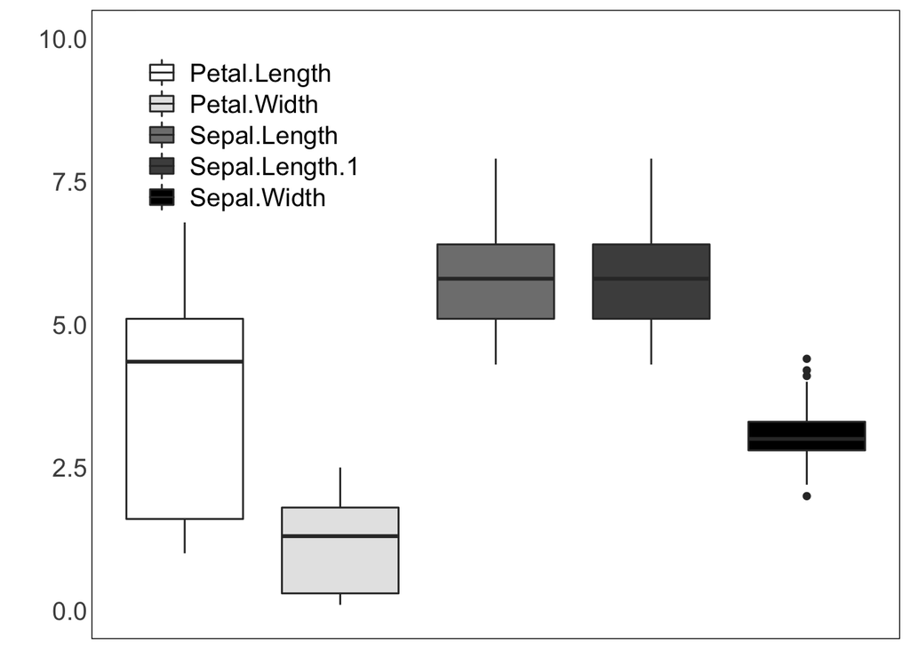

```r
df <- gather(iris[,c(1,2,3,4,1)],name, value, Sepal.Length:Sepal.Length.1)
ggplot(data = df,aes(x = name, y=value, fill=name)) +
        geom_boxplot() +
        xlab("") +
        ylab("") +
        ylim(c(0, 10)) +
        scale_x_discrete(labels = "") + # remove x lab
        scale_fill_manual(name = "",values=c("white", "grey90", "grey50", "grey30", "black")) +
        theme(panel.grid.major = element_blank(),
              panel.grid.minor = element_blank(),
              panel.background = element_blank(),
              panel.border = element_rect(colour = "black", fill=NA),
              legend.position = c(0.2, 0.83),
              axis.text.x=element_blank(),
              axis.text.y=element_text(size=14),
              axis.title=element_text(size=14),
              legend.text = element_text(size=14),
              legend.title = element_text(size=14),
              legend.key = element_blank(),
              axis.ticks.length = unit(0, "mm"), # remove a vertical line on x-axis
              axis.title.x=element_blank()) # remove x-lab position
```

## Heat map

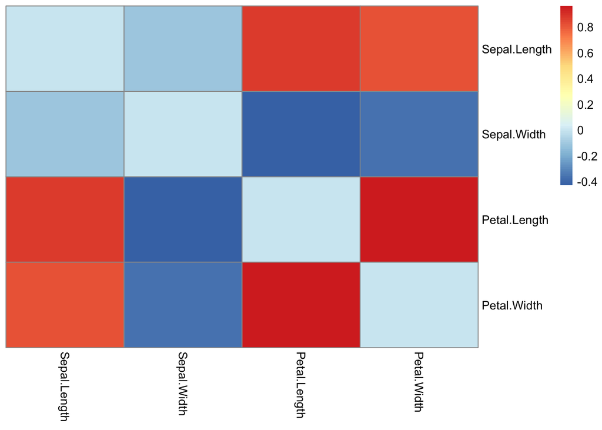

```r
library(pheatmap)


cor.mt <- matrix(NA, 4, 4)
for(i in 1:4){
    for(j in 1:4){
        # cor.mt[i-1,j-1] <- cor(phi.train[,i], phi.train[,j])
        cor.mt[i,j] <- cor(iris[,i], iris[,j])
    }
}
rownames(cor.mt) <- colnames(iris)[1:4]
colnames(cor.mt) <- colnames(iris)[1:4]
diag(cor.mt) <- 0

pheatmap(cor.mt, cluster_rows = F, cluster_cols = F)
```

## Group Bar chart

fracet_grid: [ref1](http://zevross.com/blog/2019/04/02/easy-multi-panel-plots-in-r-using-facet_wrap-and-facet_grid-from-ggplot2/), [ref2](https://www.datanovia.com/en/blog/how-to-change-ggplot-facet-labels/)

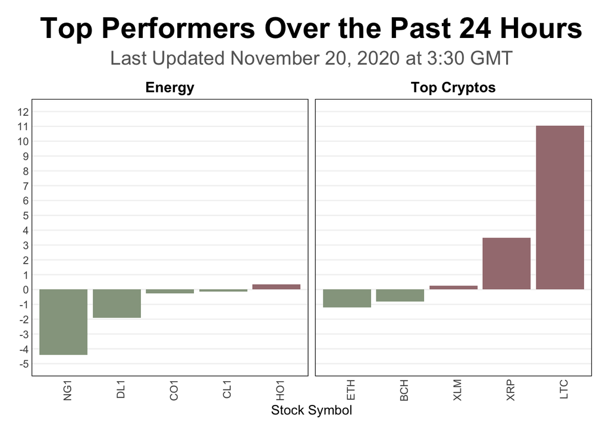

```r
data <- data.frame(Company = c("LTC", "XRP", "HO1", "XLM", "CL1",
                               "CO1", "BCH", "ETH", "DL1", "NG1"),
                   Stock = c(11.06,3.5, 0.35, 0.25, -0.15, -0.25,
                             -0.8,-1.2, -1.9, -4.42),
                   Asset.Class = c("Top Cryptos", "Top Cryptos","Energy",
                                   "Top Cryptos", "Energy", "Energy","Top Cryptos",
                                   "Top Cryptos", "Energy", "Energy"))

data$pn <- ifelse(data$Stock>0, "p", "n")
data$pn <- as.factor(data$pn)
lim_u <- max(data$Stock)
lim_l <- min(data$Stock)

ggplot(data = data, aes(x = reorder(Company, Stock),
                        y = Stock,
                        fill = pn))+
    geom_bar(position="dodge",
             stat="identity")+
    scale_y_continuous(limits=c(-5,12), breaks = seq(-5,12,1))+
    scale_fill_manual(values=c("#96A48E", "#A47C80"))+
    facet_grid(~Asset.Class, scales="free_x", space = "free_x") +
    labs(title = "Top Performers Over the Past 24 Hours",
         subtitle = "Last Updated November 20, 2020 at 3:30 GMT",
         # caption = "",
         x = "Stock Symbol") +
    theme(
        panel.grid.major.y = element_line(colour = "grey95"),
        panel.grid.minor.y = element_blank(),
        panel.grid.major.x = element_blank(),
        panel.grid.minor.x = element_blank(),
        panel.background = element_rect(fill="white"),
        panel.border = element_rect(colour = "black", fill=NA),

        plot.margin = margin(0.5, 0.5, 0.5, 0.5, "cm"),


          legend.position = "none",

          axis.text.x=element_text(angle = 90, hjust=0.95), # 股票代號靠上
          axis.title.y=element_blank(),
        axis.ticks.length = unit(0, "mm"),

          legend.text = element_text(size=14),
          legend.title = element_text(size=14),
          legend.key = element_blank(),

          plot.title = element_text(color = "Black", size = 24, face = "bold",hjust = 0.5),
          plot.subtitle = element_text(color = "Grey40", size = 16, hjust = 0.5),

          strip.background = element_rect(color="black", fill="White",  linetype=0),
          strip.text.x = element_text(size = 12, color = "black", face = "bold"
          ))
```